# final_lab_clustering

andrey

08 01 2021

## Clustering

Восстановим матрицу, которую мы делали для ассоциативных правил. Подключаем нужные пакеты для ассоциативных правил

```r
library('arules')
```

Подключаем пакет для использования регулярных выражений

```r
library(dplyr)
```

Загружаем данные, так, чтобы заголовками были названия вопросов

```r
data2 = read.csv("kaggle_survey_2020_responses.csv", skip = 1,na.strings="")
```

Убираем 1 столбец и supplementary questions

```r
data3 = data2[2:256]
```

Делаем новый датасет только из тех столбцов, в которых бинарные значения

```r
data_binary = is.na(select(data3, contains("Select.all.that.apply")))==FALSE
```

Делаем новый датасет из оставшихся столбцов

```r
data_non_binary = select(data3, !contains("Select.all.that.apply"))
```

Преобразуем датасет в факторы

```r
for (i in 1:length(data_non_binary))
{
  data_non_binary[[i]] = factor(data_non_binary[[i]])
}
```

Делаем один общий датасет из этих двух датасетов

```r
data_for_assoc = cbind(data_non_binary,data_binary)
```

Преобразуем это в обьект для использования ассоциативных правил

```r
data_assoc = as(data_for_assoc,"transactions")
```

Мы получили в data_assoc матрицу, где все бинарные переменные преобразованы в true/false, небинарные, но факторные, преобразованы в набор бинарных столбцов. Если заменить true/false на 1/0 , то данные будут полностью подходить для использования кластеризации, это получатся обьекты с кучей измерений, в каждом измерении есть только 2 значения: 0 и 1. Извлекаем из data_assoc матрицу особого типа, преобразуя в обычную матрицу и транспонируя, чтобы стала нормальная матрица, такая как нам нужно

```r
data_assoc@data@Dimnames[[1]] = data_assoc@itemInfo$labels
data_for_clustering = as.data.frame(t(as.matrix(data_assoc@data)))
```

Преобразуем true/false в 1/0

```r
for (i in 1:length(data_for_clustering))
{
  data_for_clustering[[i]] = as.integer(data_for_clustering[[i]])
}
```

Теперь данные готовы, чтобы использовать на них алгоритмы кластеризации Определяем приемлемое значение для k

```r
round_num = 10
wss <-numeric(round_num)
for (i in 1:round_num) wss[i]<-kmeans(data_for_clustering, i, nstart = 1)$tot.withinss
```

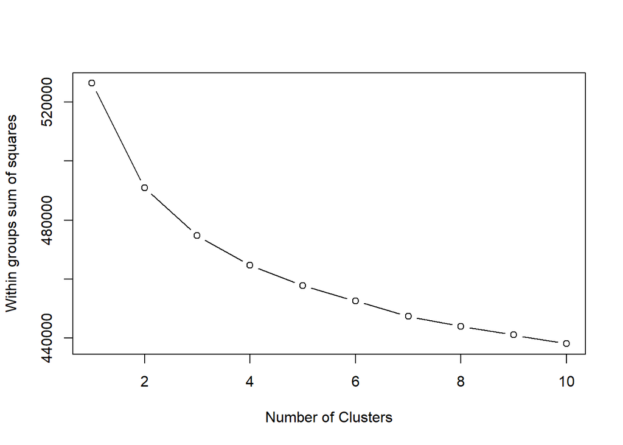

```r
plot(1:round_num, wss, type="b", xlab="Number of Clusters",ylab="Within groups sum of squares")
```

Даже с round_num=10 и 1 выбором рандомного набора время кластеризации 24 сек. Попробуем иерархическую кластеризацию. Делаем матрицу дистанций.

```r
dist_matrix = dist(data_for_clustering)
```

Выполнялось 14 минут, зато теперь мы можем проводить с ней кучу различных кластеризаций, которые будут выполняться быстро. Подумаем, какой linkage нам нужен.  
single и complete - смотреть по наибольшему и наименьшему расстоянию, тут не нужно, у нас наверняка будут промежуточные точки между реально важными кластерами. Average - тоже не хочется, он соединяет кластеры с маленькими отклонениями, тут не будет гарантии такого маленького отклонения. Поэтому остановимся на методе с центроидами.  
Проводим кластеризацию

```r
hc_centroid<-hclust(dist_matrix, "centroid")
```

Выполняется всего за 20 сек.  
Построим график высот для различных значений k.Так как для анализа результатов вручную пригодны лишь количества кластеров до 100, берем только такие значения.

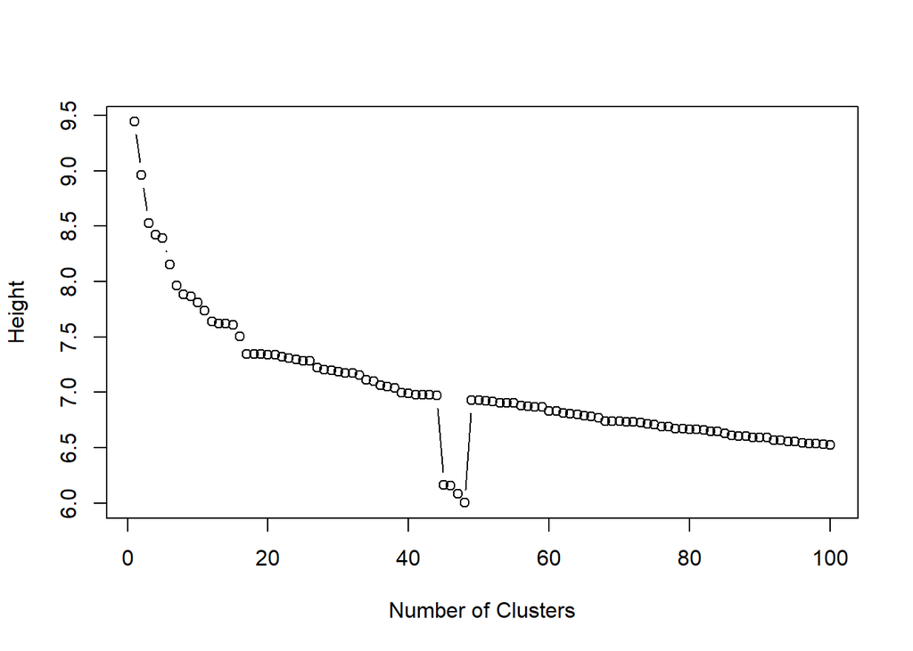

```r
plot(100:1, tail(hc_centroid$height,100), type="b", xlab="Number of Clusters",ylab="Height")
```

Локтем на графике является значение k=17. Берем такое k.

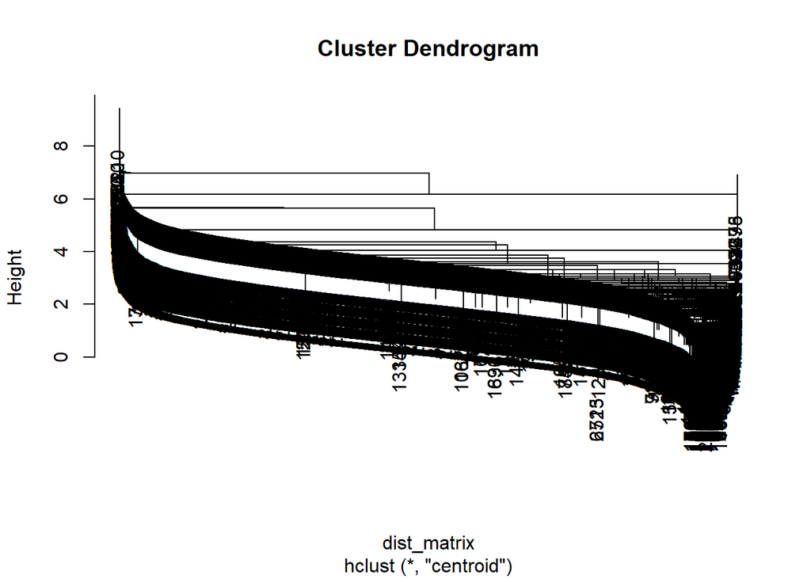

```r
cut_centroid = cutree(hc_centroid,k = 17)
plot(hc_centroid)
```

```r
table(cut_centroid)
```

```
## cut_centroid
##     1     2     3     4     5     6     7     8     9    10    11    12    13
## 20020     1     1     1     1     1     1     1     1     1     1     1     1
##    14    15    16    17
##     1     1     1     1
```

Как мы видим, с таким методом кластеризации образовался большой кластер, и далее к нему прилипали оставшиеся точки. Чтобы такого не было, попробуем другой метод кластеризации - взвешенный centroid linkage, то есть median

```r
hc_median<-hclust(dist_matrix, "median")
```

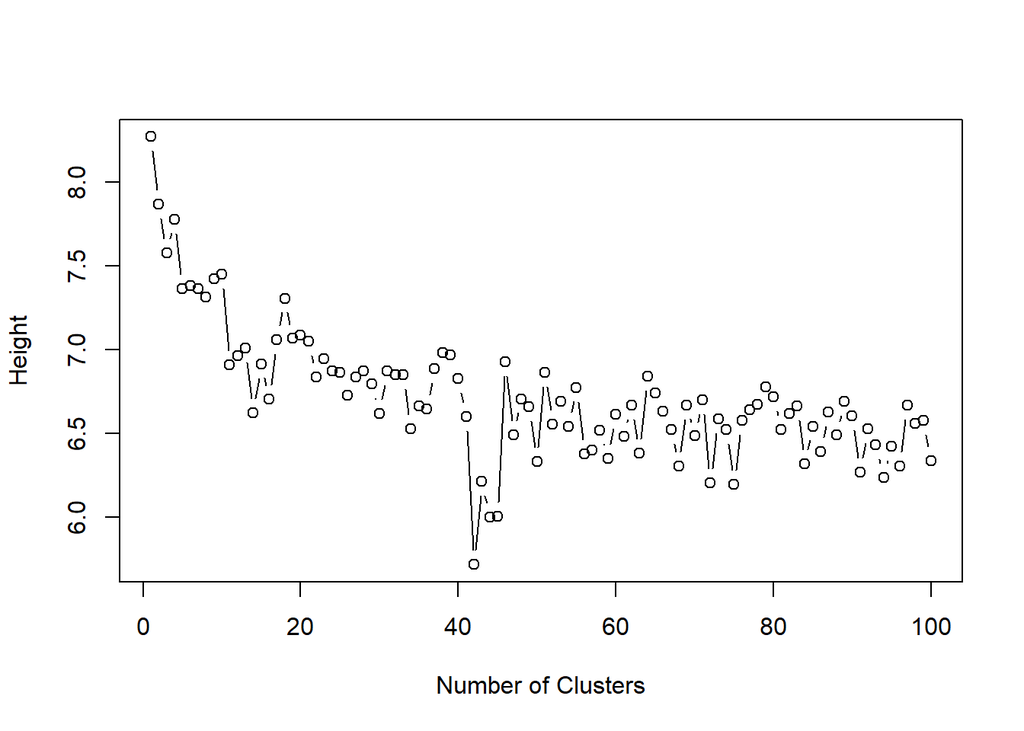

```r
plot(100:1, tail(hc_median$height,100), type="b", xlab="Number of Clusters",ylab="Height")
```

Локтем на графике является значение k=14. Берем такое k.

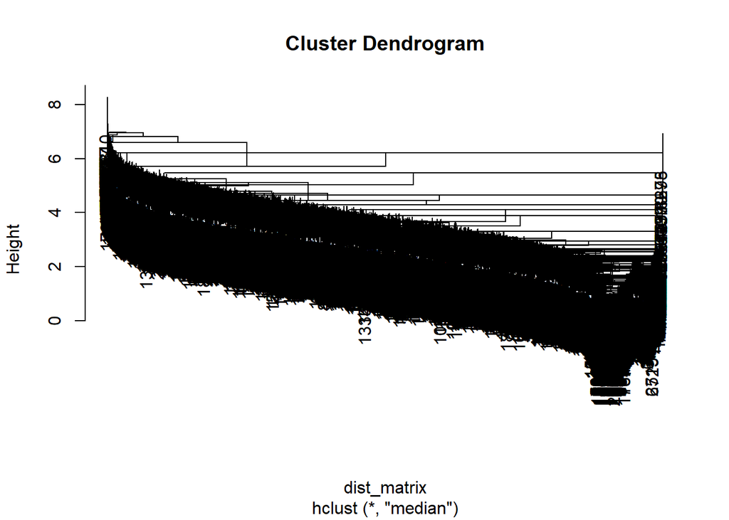

```r
cut_median = cutree(hc_median,k = 14)
plot(hc_median)
```

```r
table(cut_median)
```

```
## cut_median
##     1     2     3     4     5     6     7     8     9    10    11    12    13
## 20023     1     1     1     1     1     1     1     1     1     1     1     1
##    14
##     1
```

Тоже не подходит. Попробуем все методы кластеризации и попробуем найти тот, который даст хоть какое-то нормальное разбиение на кластеры.

```r
hc_single<-hclust(dist_matrix, "single")
cut_single = cutree(hc_single,k = 50)
table(cut_single)
```

```
## cut_single
##     1     2     3     4     5     6     7     8     9    10    11    12    13
## 19983     1     1     1     1     1     1     1     1     1     1     1     1
##    14    15    16    17    18    19    20    21    22    23    24    25    26
##     1     1     1     1     1     1     5     1     1     1     1     1     1
##    27    28    29    30    31    32    33    34    35    36    37    38    39
##     1     1     1     1     1     1     1     1     1     1     1     1     1
##    40    41    42    43    44    45    46    47    48    49    50
##     1     1     1     1     1     1     1     1     1     1     1
```

```r
hc_complete<-hclust(dist_matrix, "complete")
cut_complete = cutree(hc_complete,k = 50)
table(cut_complete)
```

```
## cut_complete
##    1    2    3    4    5    6    7    8    9   10   11   12   13   14   15   16
## 6822  332 8363 2429   83    3   63  149    8  689  154   62   68   52  133   21
##   17   18   19   20   21   22   23   24   25   26   27   28   29   30   31   32
##   30   68   44   13  116    2   10   27    5   72   19    5   30   30   41   13
##   33   34   35   36   37   38   39   40   41   42   43   44   45   46   47   48
##    4   17    8    5    4    2    5    3    4    2    4    5    1    6    4    1
##   49   50
##    4    1
```

```r
hc_average<-hclust(dist_matrix, "average")
cut_average = cutree(hc_average,k = 50)
table(cut_average)
```

```
## cut_average
##     1     2     3     4     5     6     7     8     9    10    11    12    13
## 19927     1     3     2     3     3     3     7     2     2     2     3     2
##    14    15    16    17    18    19    20    21    22    23    24    25    26
##     2     3     1     6     1     2     1     2    15     3     2     1     1
##    27    28    29    30    31    32    33    34    35    36    37    38    39
##     3     3     1     5     4     1     1     1     1     1     1     1     1
##    40    41    42    43    44    45    46    47    48    49    50
##     2     1     1     1     1     1     1     1     1     1     1
```

```r
hc_mcquitty<-hclust(dist_matrix, "mcquitty")
cut_mcquitty = cutree(hc_mcquitty,k = 50)
table(cut_mcquitty)
```

```
## cut_mcquitty
##     1     2     3     4     5     6     7     8     9    10    11    12    13
## 12739   357  2097  2737  1851     1    52    36    20     3    33     3     1
##    14    15    16    17    18    19    20    21    22    23    24    25    26
##     3    18     3     2    10     4     2     2     2     1     2     2     3
##    27    28    29    30    31    32    33    34    35    36    37    38    39
##     4     1     1     5     3     2     5     4     1     2     1     3     1
##    40    41    42    43    44    45    46    47    48    49    50
##     6     1     3     1     2     1     1     1     1     1     1
```

```r
hc_wardD<-hclust(dist_matrix, "ward.D")
cut_wardD = cutree(hc_wardD,k = 50)
table(cut_wardD)
```

```
## cut_wardD
##    1    2    3    4    5    6    7    8    9   10   11   12   13   14   15   16
##  515  410  421  360  647  259  826  432  336  318  327  411 1092  566  245  443
##   17   18   19   20   21   22   23   24   25   26   27   28   29   30   31   32
##  313  322  958  371  393  292  295  329  274  307  639  622  410  420  501  184
##   33   34   35   36   37   38   39   40   41   42   43   44   45   46   47   48
##  496  253  443  288  336  434  433  273  566  109  457  293  208  310  386  179
##   49   50
##  178  156
```

```r
hc_wardD2<-hclust(dist_matrix, "ward.D2")
cut_wardD2 = cutree(hc_wardD2,k = 50)
table(cut_wardD2)
```

```
## cut_wardD2
##    1    2    3    4    5    6    7    8    9   10   11   12   13   14   15   16
##  640  194  516  296  828  185  551  453  241  281  225  405  482  764  428  340
##   17   18   19   20   21   22   23   24   25   26   27   28   29   30   31   32
##  470  454  343  541  471  327  275  344  438  372  605  241  375  222 1180  523
##   33   34   35   36   37   38   39   40   41   42   43   44   45   46   47   48
##  263  326  304  225  454  641  429  453  292  536  337  643  298  295  256  114
##   49   50
##   34  126
```

complete и mcquitty(взвешенный average) дали разделение на кластера, ward.D и ward.D2 дали очень равные по размеру кластера. Проанализируем каждое из этих разбиений. Начнем с complete.

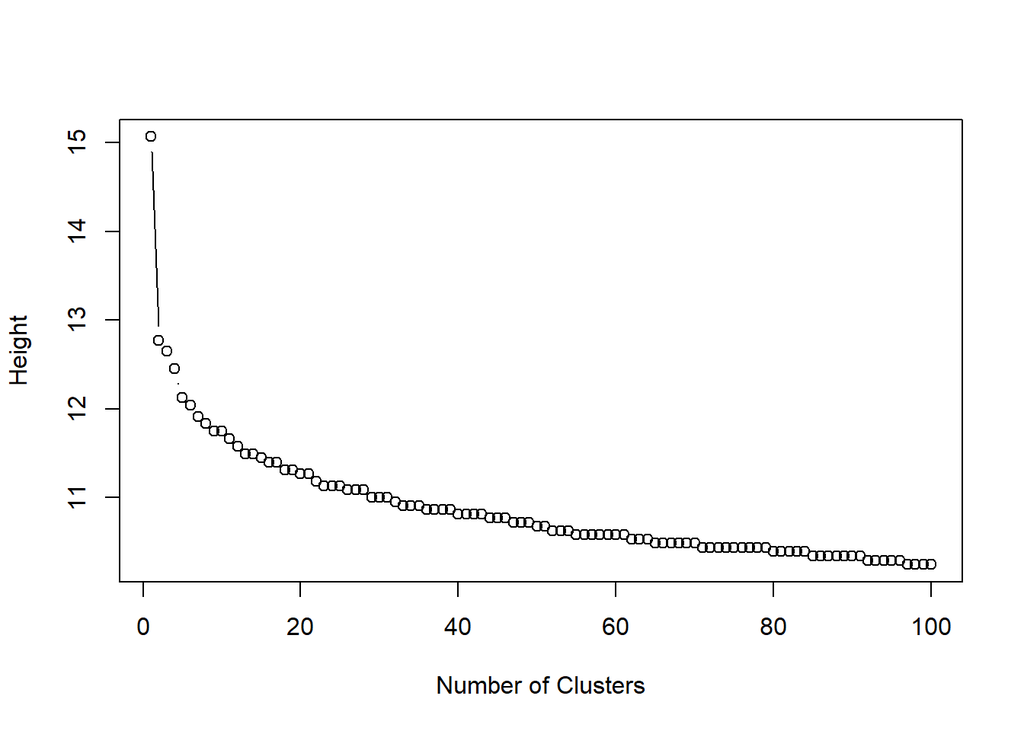

```r
plot(100:1, tail(hc_complete$height,100), type="b", xlab="Number of Clusters",ylab="Height")
```

Локоть k = 5.

```r
cut_complete = cutree(hc_complete,k = 5)
table(cut_complete)
```

```
## cut_complete
##     1     2     3     4     5
## 19459    22   158   390     7
```

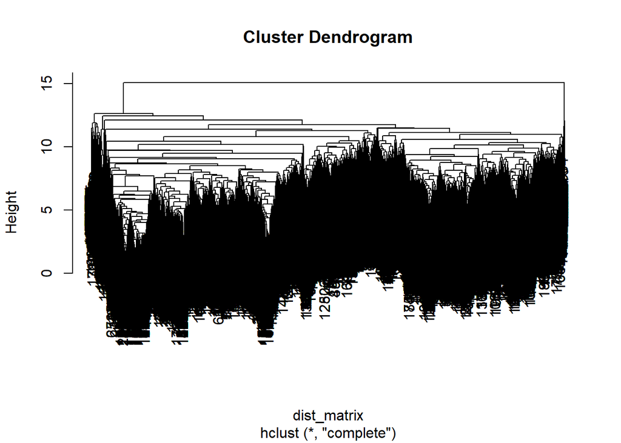

```r
plot(hc_complete)
```

В последнюю очередь присоединяются далекие от остальных отдельные точки, так не уследить за кластерами. Взвешенный average

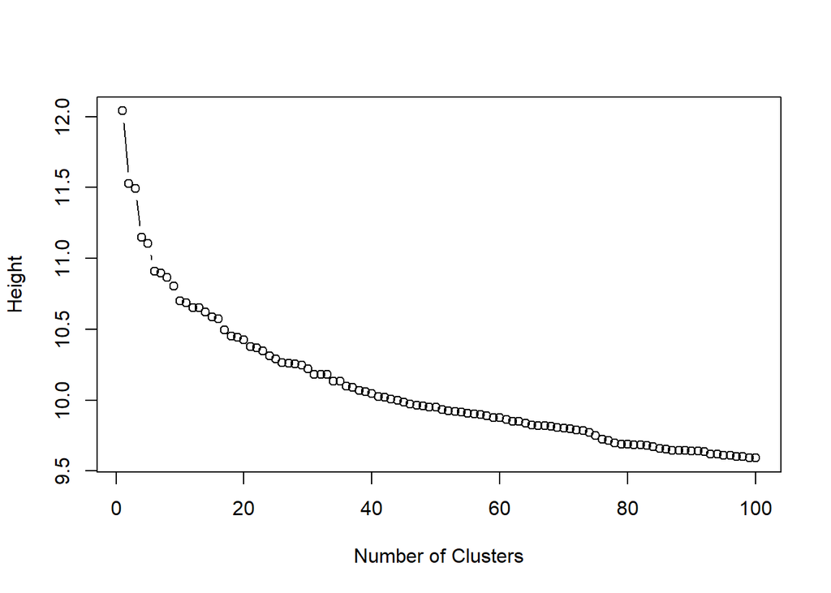

```r
plot(100:1, tail(hc_mcquitty$height,100), type="b", xlab="Number of Clusters",ylab="Height")
```

Локоть k = 10

```r
cut_mcquitty = cutree(hc_mcquitty,k = 10)
table(cut_mcquitty)
```

```
## cut_mcquitty
##     1     2     3     4     5     6     7     8     9    10
## 12779  7217     1    13    17     4     2     1     1     1
```

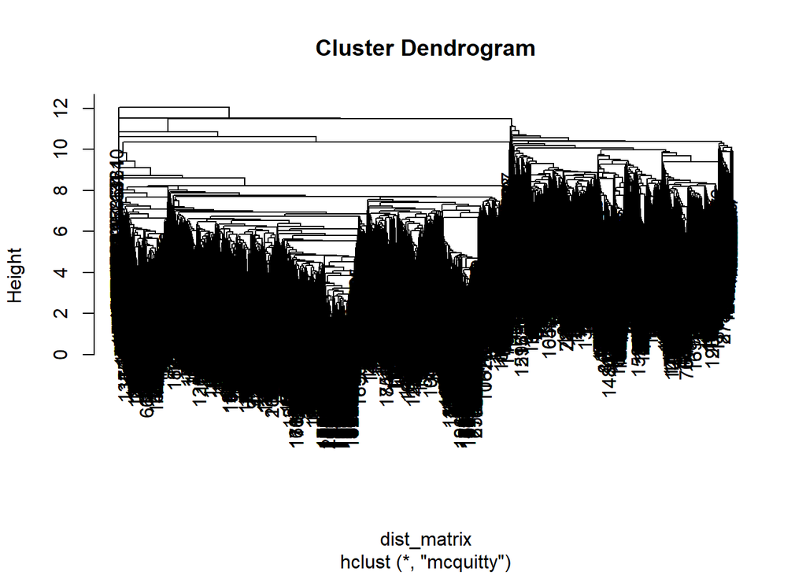

```r
plot(hc_mcquitty)
```

Тут та же самая проблема.  
Ward.D

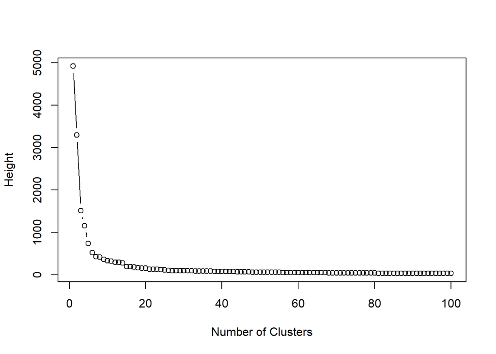

```r
plot(100:1, tail(hc_wardD$height,100), type="b", xlab="Number of Clusters",ylab="Height")
```

Локоть k = 18. Хотя много точек можно воспринимать как локти, забегая вперед скажу, что количество кластеров до 10 не сделает полноценного разделения, и лучше количество кластеров брать исходя из дендрограммы, когда видишь внизу нее маленькие сгустки.

```r
cut_wardD = cutree(hc_wardD,k = 18)
table(cut_wardD)
```

```
## cut_wardD
##    1    2    3    4    5    6    7    8    9   10   11   12   13   14   15   16
## 1135 1995  421 1236  692 1119 1959  971  411 1276  811 1897 1494 1062  951 1096
##   17   18
##  501 1009
```

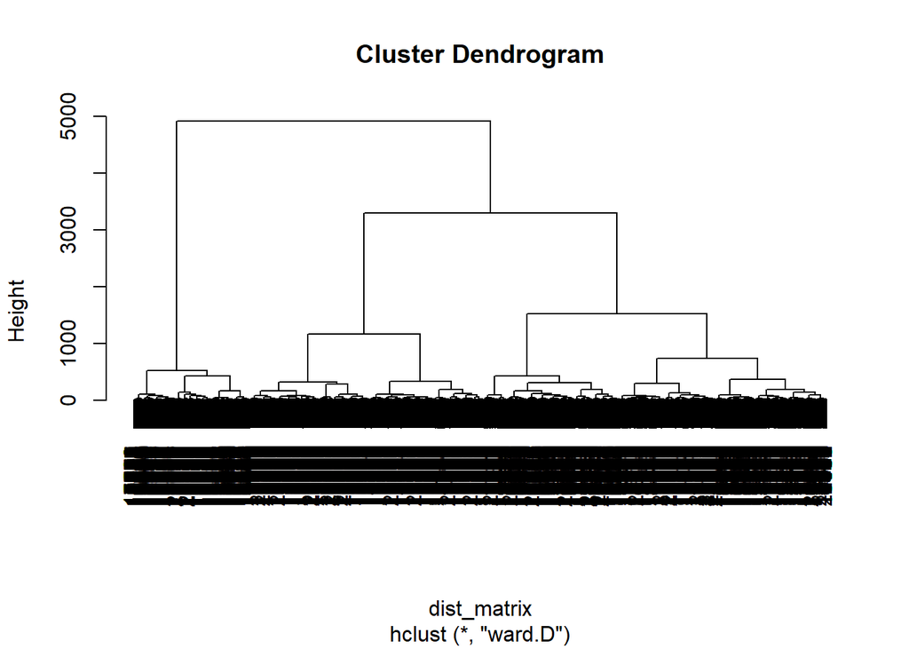

```r
plot(hc_wardD)
```

Наконец-то нормальное разделение  
Ward.D2

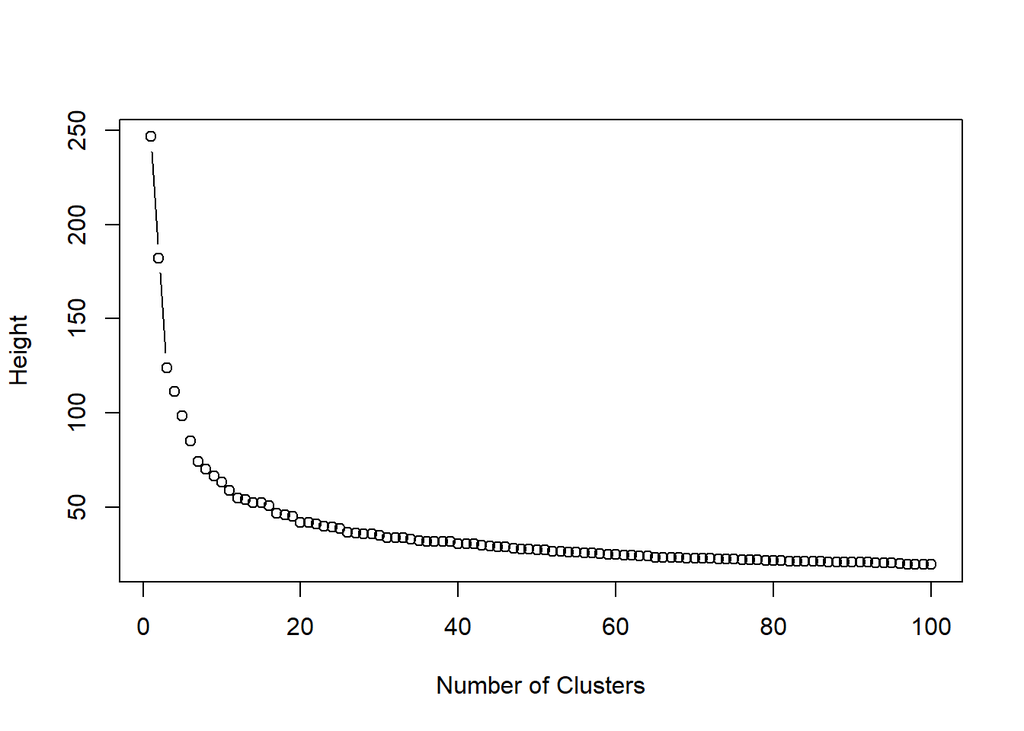

```r
plot(100:1, tail(hc_wardD2$height,100), type="b", xlab="Number of Clusters",ylab="Height")
```

Локоть k = 7

```r
cut_wardD2 = cutree(hc_wardD2,k = 7)
table(cut_wardD2)
```

```
## cut_wardD2
##    1    2    3    4    5    6    7
## 3406 2772 1722 3028 3066 2502 3540
```

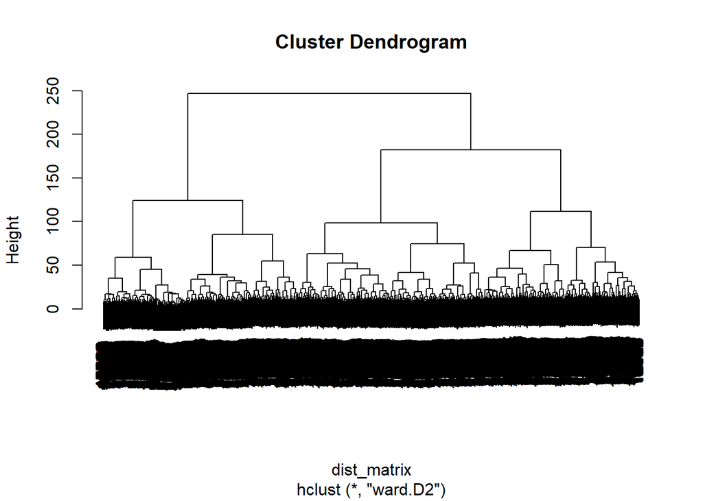

```r
plot(hc_wardD2)
```

Посмотрим на получившиеся центроиды. Так как hclust не дает по умолчанию их координаты, придется их высчитывать вручную. summary_frame_wardD будет содержать координаты всех центроидов в измерениях, соответствующих вопросам. По сути, каждая такая координата представляет собой вероятность, что человек из данного кластера ответит на данный вопрос.

```r
cut_wardD_factor = factor(cut_wardD)
summary_frame_wardD = head(data_for_clustering,length(levels(cut_wardD_factor)))
for (i in 1:length(summary_frame_wardD))
{
  summary_frame_wardD[[i]] = tapply(data_for_clustering[[i]],cut_wardD_factor,mean)
}
```

Скорее всего кластеры должны характеризоваться наличием каких то общих признаков, вероятность появления этих признаков должна быть больше, чем в среднем по датасету. Поэтому делим значения в колонках на средние значения для данной колонки в датасете, чтобы узнать, относительно всего датасета, во сколько раз чаще появляется этот признак у того или иного кластера

```r
factor_massiv = factor(integer(length(data_for_clustering[[1]])))
for (i in 1:length(summary_frame_wardD))
{
  summary_frame_wardD[[i]] = summary_frame_wardD[[i]]/as.numeric(tapply(data_for_clustering[[i]],factor_massiv,mean))
}
```

И теперь, чтобы увидеть самые характерные признаки для каждого кластера, выводим топ таких признаков. Чтобы функция tail сработала, транспонируем промежуточный результат сортировки. Итак, первый кластер

```r
tail(t(sort(summary_frame_wardD[1,])),20)
```

```
##                                                                                                                                                                                                                                                     1
## What.is.your.age....years..=18-21                                                                                                                                                                                                            2.035499
## Which.of.the.following.machine.learning.frameworks.do.you.use.on.a.regular.basis...Select.all.that.apply....Selected.Choice....PyTorch                                                                                                       2.048052
## Which.categories.of.computer.vision.methods.do.you.use.on.a.regular.basis....Select.all.that.apply....Selected.Choice...None                                                                                                                 2.082211
## Which.of.the.following.machine.learning.frameworks.do.you.use.on.a.regular.basis...Select.all.that.apply....Selected.Choice.....TensorFlow                                                                                                   2.125777
## Which.categories.of.computer.vision.methods.do.you.use.on.a.regular.basis....Select.all.that.apply....Selected.Choice...Object.detection.methods..YOLOv3..RetinaNet..etc.                                                                    2.148232
## Which.of.the.following.machine.learning.frameworks.do.you.use.on.a.regular.basis...Select.all.that.apply....Selected.Choice....Keras                                                                                                         2.160993
## Which.of.the.following.ML.algorithms.do.you.use.on.a.regular.basis...Select.all.that.apply.....Selected.Choice...Dense.Neural.Networks..MLPs..etc.                                                                                           2.167251
## Which.of.the.following.ML.algorithms.do.you.use.on.a.regular.basis...Select.all.that.apply.....Selected.Choice...Recurrent.Neural.Networks                                                                                                   2.188792
## In.which.country.do.you.currently.reside.=China                                                                                                                                                                                              2.197297
## In.which.country.do.you.currently.reside.=Bangladesh                                                                                                                                                                                         2.222039
## Which.categories.of.computer.vision.methods.do.you.use.on.a.regular.basis....Select.all.that.apply....Selected.Choice...General.purpose.image.video.tools..PIL..cv2..skimage..etc.                                                           2.228272
## In.which.country.do.you.currently.reside.=Taiwan                                                                                                                                                                                             2.247930
## Which.categories.of.computer.vision.methods.do.you.use.on.a.regular.basis....Select.all.that.apply....Selected.Choice...Image.segmentation.methods..U.Net..Mask.R.CNN..etc.                                                                  2.264995
## Which.of.the.following.ML.algorithms.do.you.use.on.a.regular.basis...Select.all.that.apply.....Selected.Choice...Generative.Adversarial.Networks                                                                                             2.275564
## For.how.many.years.have.you.used.machine.learning.methods.=1-2 years                                                                                                                                                                         2.291453
## Which.categories.of.computer.vision.methods.do.you.use.on.a.regular.basis....Select.all.that.apply....Selected.Choice...Image.classification.and.other.general.purpose.networks..VGG..Inception..ResNet..ResNeXt..NASNet..EfficientNet..etc. 2.332269
## Which.of.the.following.natural.language.processing..NLP..methods.do.you.use.on.a.regular.basis....Select.all.that.apply....Selected.Choice...None                                                                                            2.360459
## Which.of.the.following.ML.algorithms.do.you.use.on.a.regular.basis...Select.all.that.apply.....Selected.Choice...Convolutional.Neural.Networks                                                                                               2.449527
## Which.categories.of.computer.vision.methods.do.you.use.on.a.regular.basis....Select.all.that.apply....Selected.Choice...Generative.Networks..GAN..VAE..etc.                                                                                  2.473341
## Select.the.title.most.similar.to.your.current.role..or.most.recent.title.if.retired.....Selected.Choice=Student                                                                                                                              2.819815
```

Чтобы понимать, что общее во многих кластерах, нужно быть экспертом в предметной области. Но тут мы видим, что первый кластер выделяют люди, которые используют нейронные сети и компьютерное зрение, используют соответствующие инструменты для этого, такие как PyTorch, TensorFlow,Keras. Среди свойств видны характерные для этого кластера методы, инструменты. При этом среди таких много молодых студентов, особенно из Азии, которые решили преисполниться в новой модной области.  
Кластер 2

```r
tail(t(sort(summary_frame_wardD[2,])),20)
```

```
##                                                                                                                                                                                                                               2
## Do.you.use.any.of.the.following.cloud.computing.products.on.a.regular.basis...Select.all.that.apply....Selected.Choice....Microsoft.Azure.Container.Instances                                                          4.832624
## Which.of.the.following.business.intelligence.tools.do.you.use.most.often....Selected.Choice=Alteryx                                                                                                                    4.835570
## Do.you.use.any.of.the.following.cloud.computing.products.on.a.regular.basis...Select.all.that.apply....Selected.Choice....AWS.Lambda                                                                                   4.836354
## Do.you.use.any.of.the.following.machine.learning.products.on.a.regular.basis...Select.all.that.apply....Selected.Choice....Amazon.SageMaker                                                                            4.873861
## Do.you.use.any.of.the.following.cloud.computing.products.on.a.regular.basis...Select.all.that.apply....Selected.Choice....Azure.Functions                                                                              4.999816
## Which.of.the.following.big.data.products..relational.databases..data.warehouses..data.lakes..or.similar..do.you.use.on.a.regular.basis...Select.all.that.apply....Selected.Choice...Google.Cloud.BigQuery.             5.044072
## Which.of.the.following.big.data.products..relational.database..data.warehouse..data.lake..or.similar..do.you.use.most.often....Selected.Choice=Other                                                                   5.076736
## Do.you.use.any.of.the.following.machine.learning.products.on.a.regular.basis...Select.all.that.apply....Selected.Choice....Azure.Machine.Learning.Studio                                                               5.077143
## Do.you.use.any.of.the.following.cloud.computing.products.on.a.regular.basis...Select.all.that.apply....Selected.Choice....Azure.Cloud.Services                                                                         5.162345
## Do.you.use.any.of.the.following.cloud.computing.products.on.a.regular.basis...Select.all.that.apply....Selected.Choice...Other                                                                                         5.173722
## Which.of.the.following.big.data.products..relational.databases..data.warehouses..data.lakes..or.similar..do.you.use.on.a.regular.basis...Select.all.that.apply....Selected.Choice...Snowflake.                         5.223888
## Which.of.the.following.big.data.products..relational.databases..data.warehouses..data.lakes..or.similar..do.you.use.on.a.regular.basis...Select.all.that.apply....Selected.Choice...Amazon.Athena.                     5.362825
## Which.of.the.following.big.data.products..relational.databases..data.warehouses..data.lakes..or.similar..do.you.use.on.a.regular.basis...Select.all.that.apply....Selected.Choice...Amazon.Redshift.                   5.395620
## Which.of.the.following.big.data.products..relational.databases..data.warehouses..data.lakes..or.similar..do.you.use.on.a.regular.basis...Select.all.that.apply....Selected.Choice...Microsoft.Azure.Data.Lake.Storage. 5.461229
## Which.of.the.following.big.data.products..relational.database..data.warehouse..data.lake..or.similar..do.you.use.most.often....Selected.Choice=Amazon Athena                                                           5.550139
## Which.of.the.following.business.intelligence.tools.do.you.use.most.often....Selected.Choice=Looker                                                                                                                     5.814431
## Which.of.the.following.big.data.products..relational.database..data.warehouse..data.lake..or.similar..do.you.use.most.often....Selected.Choice=Amazon Redshift                                                         6.089128
## Which.of.the.following.big.data.products..relational.database..data.warehouse..data.lake..or.similar..do.you.use.most.often....Selected.Choice=Google Cloud BigQuery                                                   6.246909
## Which.of.the.following.big.data.products..relational.database..data.warehouse..data.lake..or.similar..do.you.use.most.often....Selected.Choice=Microsoft Azure Data Lake Storage                                       6.266213
## Which.of.the.following.big.data.products..relational.database..data.warehouse..data.lake..or.similar..do.you.use.most.often....Selected.Choice=Snowflake                                                               6.416430
```

Тут мы видим повышенное число людей, пользующихся облачными вычислениями и другими средствами крупных компаний Amazon, Google, Microsoft. Исходя из результатов исследования ассоциативных правил, можно предположить, что этот кластер в дальнейшем разделился бы на пользователей средств Amazon, пользователей Google и Microsoft Azure.  
Кластер 3

```r
tail(t(sort(summary_frame_wardD[3,])),20)
```

```
##                                                                                                                                                                                                 3
## Select.the.title.most.similar.to.your.current.role..or.most.recent.title.if.retired.....Selected.Choice=Other                                                                            3.726216
## Does.your.current.employer.incorporate.machine.learning.methods.into.their.business.=I do not know                                                                                       3.746178
## Approximately.how.many.individuals.are.responsible.for.data.science.workloads.at.your.place.of.business.=0                                                                               3.780726
## Do.you.use.any.tools.to.help.manage.machine.learning.experiments...Select.all.that.apply....Selected.Choice...No...None                                                                  3.952544
## Does.your.current.employer.incorporate.machine.learning.methods.into.their.business.=No (we do not use ML methods)                                                                       4.026639
## Do.you.use.any.automated.machine.learning.tools..or.partial.AutoML.tools..on.a.regular.basis....Select.all.that.apply....Selected.Choice...No...None                                     4.027829
## Where.do.you.publicly.share.or.deploy.your.data.analysis.or.machine.learning.applications...Select.all.that.apply....Selected.Choice...Other                                             4.098785
## What.is.your.age....years..=70+                                                                                                                                                          4.383423
## What.programming.language.would.you.recommend.an.aspiring.data.scientist.to.learn.first....Selected.Choice=Other                                                                         4.412452
## Who.what.are.your.favorite.media.sources.that.report.on.data.science.topics...Select.all.that.apply....Selected.Choice...None                                                            4.710653
## Which.of.the.following.business.intelligence.tools.do.you.use.on.a.regular.basis...Select.all.that.apply....Selected.Choice...None                                                       5.139566
## Where.do.you.publicly.share.or.deploy.your.data.analysis.or.machine.learning.applications...Select.all.that.apply....Selected.Choice...I.do.not.share.my.work.publicly                   5.402051
## What.type.of.computing.platform.do.you.use.most.often.for.your.data.science.projects....Selected.Choice=None                                                                             5.541470
## Select.any.activities.that.make.up.an.important.part.of.your.role.at.work...Select.all.that.apply....Selected.Choice...None.of.these.activities.are.an.important.part.of.my.role.at.work 5.646903
## What.data.visualization.libraries.or.tools.do.you.use.on.a.regular.basis....Select.all.that.apply....Selected.Choice...None                                                              5.770181
## Which.of.the.following.integrated.development.environments..IDE.s..do.you.use.on.a.regular.basis....Select.all.that.apply....Selected.Choice...None                                      6.904459
## Which.of.the.following.cloud.computing.platforms.do.you.use.on.a.regular.basis...Select.all.that.apply....Selected.Choice...None                                                         7.823962
## Which.of.the.following.big.data.products..relational.databases..data.warehouses..data.lakes..or.similar..do.you.use.on.a.regular.basis...Select.all.that.apply....Selected.Choice...None 7.931908
## For.how.many.years.have.you.used.machine.learning.methods.=I do not use machine learning methods                                                                                         8.761414
## What.programming.languages.do.you.use.on.a.regular.basis...Select.all.that.apply....Selected.Choice...None                                                                               9.241058
```

```r
tail(t(sort(summary_frame_wardD[4,])),20)
```

```
##                                                                                                                                               4
## What.programming.languages.do.you.use.on.a.regular.basis...Select.all.that.apply....Selected.Choice...None                             1.573821
## In.which.country.do.you.currently.reside.=Taiwan                                                                                       1.578537
## In.which.country.do.you.currently.reside.=Morocco                                                                                      1.584471
## For.how.many.years.have.you.been.writing.code.and.or.programming.=< 1 years                                                            1.585317
## What.programming.language.would.you.recommend.an.aspiring.data.scientist.to.learn.first....Selected.Choice=C                           1.615650
## In.which.country.do.you.currently.reside.=Egypt                                                                                        1.630092
## What.is.your.age....years..=18-21                                                                                                      1.677578
## What.programming.language.would.you.recommend.an.aspiring.data.scientist.to.learn.first....Selected.Choice=Java                        1.747224
## What.programming.language.would.you.recommend.an.aspiring.data.scientist.to.learn.first....Selected.Choice=C++                         1.795609
## Select.the.title.most.similar.to.your.current.role..or.most.recent.title.if.retired.....Selected.Choice=Student                        1.799409
## What.programming.language.would.you.recommend.an.aspiring.data.scientist.to.learn.first....Selected.Choice=Other                       1.825007
## In.which.country.do.you.currently.reside.=China                                                                                        1.983546
## What.programming.language.would.you.recommend.an.aspiring.data.scientist.to.learn.first....Selected.Choice=Javascript                  2.026294
## What.is.the.highest.level.of.formal.education.that.you.have.attained.or.plan.to.attain.within.the.next.2.years.=I prefer not to answer 2.072000
## What.is.your.gender....Selected.Choice=Nonbinary                                                                                       2.182163
## What.is.your.gender....Selected.Choice=Prefer to self-describe                                                                         2.401534
## What.programming.language.would.you.recommend.an.aspiring.data.scientist.to.learn.first....Selected.Choice=MATLAB                      2.577031
## What.programming.language.would.you.recommend.an.aspiring.data.scientist.to.learn.first....Selected.Choice=None                        2.601662
## In.which.country.do.you.currently.reside.=Malaysia                                                                                     2.681412
## What.is.your.gender....Selected.Choice=Prefer not to say                                                                               2.773635
```

Тут у нас люди, которые еще новички в data science. Это молодые студенты, они пока что изучают основные языки программирования, которые даже не так сильно относятся к data science. Причем тут много людей нетрадиционного гендера, это обьясняется современной культурой, в которой они варятся, и наличием в свойствах некоторых стран Юго-Восточной Азии, особенно Малайзии, в одной из этих стран считается, что там очень много таких небинарных людей(Таиланд или Филлипины, не помню в какой из них).  
Кластер 5

```r
tail(t(sort(summary_frame_wardD[5,])),20)
```

```
##                                                                                                                                                                                              5
## Which.of.the.following.machine.learning.frameworks.do.you.use.on.a.regular.basis...Select.all.that.apply....Selected.Choice....H2O.3                                                  2.020030
## Which.of.the.following.machine.learning.frameworks.do.you.use.on.a.regular.basis...Select.all.that.apply....Selected.Choice...Other                                                   2.029104
## In.which.country.do.you.currently.reside.=South Africa                                                                                                                                2.053458
## What.is.your.current.yearly.compensation..approximate..USD..=60,000-69,999                                                                                                            2.057988
## What.is.your.current.yearly.compensation..approximate..USD..=200,000-249,999                                                                                                          2.265946
## In.which.country.do.you.currently.reside.=Italy                                                                                                                                       2.385703
## In.which.country.do.you.currently.reside.=Belgium                                                                                                                                     2.412813
## Which.of.the.following.hosted.notebook.products.do.you.use.on.a.regular.basis....Select.all.that.apply....Selected.Choice...None                                                      2.466715
## Approximately.how.much.money.have.you..or.your.team..spent.on.machine.learning.and.or.cloud.computing.services.at.home..or.at.work..in.the.past.5.years..approximate..USD..=$0 ($USD) 2.643082
## In.which.country.do.you.currently.reside.=Kenya                                                                                                                                       2.838604
## What.is.the.primary.tool.that.you.use.at.work.or.school.to.analyze.data...Include.text.response....Selected.Choice=Advanced statistical software (SPSS, SAS, etc.)                    2.854596
## What.data.visualization.libraries.or.tools.do.you.use.on.a.regular.basis....Select.all.that.apply....Selected.Choice....Ggplot...ggplot2                                              3.837076
## What.programming.languages.do.you.use.on.a.regular.basis...Select.all.that.apply....Selected.Choice...R                                                                               4.264874
## What.data.visualization.libraries.or.tools.do.you.use.on.a.regular.basis....Select.all.that.apply....Selected.Choice....Shiny                                                         4.379988
## Which.of.the.following.machine.learning.frameworks.do.you.use.on.a.regular.basis...Select.all.that.apply....Selected.Choice...None                                                    4.410175
## Which.of.the.following.integrated.development.environments..IDE.s..do.you.use.on.a.regular.basis....Select.all.that.apply....Selected.Choice....RStudio                               4.707067
## Which.of.the.following.machine.learning.frameworks.do.you.use.on.a.regular.basis...Select.all.that.apply....Selected.Choice....Caret                                                  5.149390
## Which.of.the.following.machine.learning.frameworks.do.you.use.on.a.regular.basis...Select.all.that.apply....Selected.Choice....Tidymodels                                             5.683072
## Select.the.title.most.similar.to.your.current.role..or.most.recent.title.if.retired.....Selected.Choice=Statistician                                                                  6.988838
## What.programming.language.would.you.recommend.an.aspiring.data.scientist.to.learn.first....Selected.Choice=R                                                                          7.290184
```

В этом кластере сгруппировались активные пользователи языка R. В свойствах перечислены куча пакетов R, таких как ggplot2,Shiny,RStudio,Caret,Tidymodels, а как же среда Rstudio. Причем, так как это R, эти люди статистики, и в их свойства попало так же использование продвинутых статистических средств, таких как SPSS, SAS. Некоторые страны, указанные в различных кластерах, для них нету обьяснения, как они туда попали: для них можно считать, что мы установили некое предпочтение у этих стран в плане тех методов, которые они любят использовать. Так, статистиков на R больше, чем в среднем, в Италии, Кении и Бельгии.  
Кластер 6

```r
tail(t(sort(summary_frame_wardD[6,])),20)
```

```
##                                                                                                                                                                                      6
## Which.of.the.following.machine.learning.frameworks.do.you.use.on.a.regular.basis...Select.all.that.apply....Selected.Choice.....Scikit.learn                                  1.629817
## Which.of.the.following.ML.algorithms.do.you.use.on.a.regular.basis...Select.all.that.apply.....Selected.Choice...Decision.Trees.or.Random.Forests                             1.631080
## What.is.your.age....years..=22-24                                                                                                                                             1.631622
## Which.of.the.following.ML.algorithms.do.you.use.on.a.regular.basis...Select.all.that.apply.....Selected.Choice...Linear.or.Logistic.Regression                                1.656577
## Who.what.are.your.favorite.media.sources.that.report.on.data.science.topics...Select.all.that.apply....Selected.Choice...Kaggle..notebooks..forums..etc.                      1.665341
## Who.what.are.your.favorite.media.sources.that.report.on.data.science.topics...Select.all.that.apply....Selected.Choice...YouTube..Kaggle.YouTube..Cloud.AI.Adventures..etc.   1.675620
## On.which.platforms.have.you.begun.or.completed.data.science.courses...Select.all.that.apply....Selected.Choice...Udemy                                                        1.675958
## For.how.many.years.have.you.been.writing.code.and.or.programming.=1-2 years                                                                                                   1.685202
## What.data.visualization.libraries.or.tools.do.you.use.on.a.regular.basis....Select.all.that.apply....Selected.Choice....Seaborn                                               1.721310
## What.is.the.primary.tool.that.you.use.at.work.or.school.to.analyze.data...Include.text.response....Selected.Choice=Local development environments (RStudio, JupyterLab, etc.) 1.735700
## What.is.your.age....years..=18-21                                                                                                                                             1.811689
## Which.of.the.following.hosted.notebook.products.do.you.use.on.a.regular.basis....Select.all.that.apply....Selected.Choice....IBM.Watson.Studio                                1.862487
## For.how.many.years.have.you.been.writing.code.and.or.programming.=< 1 years                                                                                                   1.929424
## On.which.platforms.have.you.begun.or.completed.data.science.courses...Select.all.that.apply....Selected.Choice...Kaggle.Learn.Courses                                         1.970578
## On.which.platforms.have.you.begun.or.completed.data.science.courses...Select.all.that.apply....Selected.Choice...Other                                                        2.013796
## In.which.country.do.you.currently.reside.=Ghana                                                                                                                               2.065993
## In.which.country.do.you.currently.reside.=Nigeria                                                                                                                             2.294583
## For.how.many.years.have.you.used.machine.learning.methods.=Under 1 year                                                                                                       2.550196
## Select.the.title.most.similar.to.your.current.role..or.most.recent.title.if.retired.....Selected.Choice=Student                                                               2.579661
## Select.the.title.most.similar.to.your.current.role..or.most.recent.title.if.retired.....Selected.Choice=Currently not employed                                                3.760974
```

Этот кластер характеризуются студентами, которые пишут код и программируют не более 2 лет, используют популярные алгоритмы - регрессии и деревья с вариациями,они пользуются различными ноутбуками, например кагловским или от IBM, используют тривиальные места получения информации о data science - кагл и ютуб, могут ходить на курсы Udemy и пользоваться python. Вообщем начинающие в data science.  
Кластер 7

```r
tail(t(sort(summary_frame_wardD[7,])),20)
```

```
##                                                                                                                                                          7
## What.data.visualization.libraries.or.tools.do.you.use.on.a.regular.basis....Select.all.that.apply....Selected.Choice...None                       1.455704
## Which.of.the.following.hosted.notebook.products.do.you.use.on.a.regular.basis....Select.all.that.apply....Selected.Choice....Amazon.EMR.Notebooks 1.461095
## What.programming.language.would.you.recommend.an.aspiring.data.scientist.to.learn.first....Selected.Choice=C++                                    1.479078
## Which.types.of.specialized.hardware.do.you.use.on.a.regular.basis....Select.all.that.apply....Selected.Choice...Other                             1.489615
## In.which.country.do.you.currently.reside.=Bangladesh                                                                                              1.501965
## Which.of.the.following.hosted.notebook.products.do.you.use.on.a.regular.basis....Select.all.that.apply....Selected.Choice....Code.Ocean           1.558502
## What.is.your.age....years..=22-24                                                                                                                 1.591151
## Which.of.the.following.hosted.notebook.products.do.you.use.on.a.regular.basis....Select.all.that.apply....Selected.Choice...Other                 1.602686
## In.which.country.do.you.currently.reside.=Malaysia                                                                                                1.614895
## What.is.your.age....years..=18-21                                                                                                                 1.651050
## What.programming.language.would.you.recommend.an.aspiring.data.scientist.to.learn.first....Selected.Choice=Java                                   1.714818
## What.programming.language.would.you.recommend.an.aspiring.data.scientist.to.learn.first....Selected.Choice=C                                      1.766906
## For.how.many.years.have.you.used.machine.learning.methods.=Under 1 year                                                                           1.779147
## In.which.country.do.you.currently.reside.=Sri Lanka                                                                                               1.846662
## For.how.many.years.have.you.been.writing.code.and.or.programming.=< 1 years                                                                       1.957241
## Select.the.title.most.similar.to.your.current.role..or.most.recent.title.if.retired.....Selected.Choice=Student                                   2.128209
## Which.of.the.following.machine.learning.frameworks.do.you.use.on.a.regular.basis...Select.all.that.apply....Selected.Choice...None                2.192852
## What.programming.language.would.you.recommend.an.aspiring.data.scientist.to.learn.first....Selected.Choice=Swift                                  2.406510
## Select.the.title.most.similar.to.your.current.role..or.most.recent.title.if.retired.....Selected.Choice=Currently not employed                    2.519770
## Which.of.the.following.ML.algorithms.do.you.use.on.a.regular.basis...Select.all.that.apply.....Selected.Choice...None                             2.723672
```

Про этих людей нельзя что то сказать конкретного, просто программисты, которые пользуются ноутбуками, но не из популярных. Про этот кластер нельзя точно что то сказать, возможно он возник случайно.  
Кластер 8

```r
tail(t(sort(summary_frame_wardD[8,])),20)
```

```
##                                                                                                                                                                                                              8
## Do.you.use.any.of.the.following.cloud.computing.products.on.a.regular.basis...Select.all.that.apply....Selected.Choice...No...None                                                                    3.871333
## Which.of.the.following.business.intelligence.tools.do.you.use.on.a.regular.basis...Select.all.that.apply....Selected.Choice...TIBCO.Spotfire                                                          3.884122
## What.programming.language.would.you.recommend.an.aspiring.data.scientist.to.learn.first....Selected.Choice=Other                                                                                      3.962898
## Which.of.the.following.big.data.products..relational.databases..data.warehouses..data.lakes..or.similar..do.you.use.on.a.regular.basis...Select.all.that.apply....Selected.Choice...Other             3.963670
## Which.of.the.following.big.data.products..relational.database..data.warehouse..data.lake..or.similar..do.you.use.most.often....Selected.Choice=Microsoft SQL Server                                   4.142969
## Which.of.the.following.business.intelligence.tools.do.you.use.on.a.regular.basis...Select.all.that.apply....Selected.Choice...Qlik                                                                    4.152835
## Which.of.the.following.business.intelligence.tools.do.you.use.on.a.regular.basis...Select.all.that.apply....Selected.Choice...Other                                                                   4.186689
## Which.of.the.following.business.intelligence.tools.do.you.use.on.a.regular.basis...Select.all.that.apply....Selected.Choice...SAP.Analytics.Cloud                                                     4.248258
## Which.of.the.following.big.data.products..relational.databases..data.warehouses..data.lakes..or.similar..do.you.use.on.a.regular.basis...Select.all.that.apply....Selected.Choice...Microsoft.Access. 4.260005
## Do.you.use.any.tools.to.help.manage.machine.learning.experiments...Select.all.that.apply....Selected.Choice....Comet.ml                                                                               4.421657
## Which.of.the.following.cloud.computing.platforms.do.you.use.on.a.regular.basis...Select.all.that.apply....Selected.Choice....Oracle.Cloud                                                             4.617488
## Which.of.the.following.cloud.computing.platforms.do.you.use.on.a.regular.basis...Select.all.that.apply....Selected.Choice...Other                                                                     4.632212
## Which.of.the.following.business.intelligence.tools.do.you.use.most.often....Selected.Choice=TIBCO Spotfire                                                                                            4.689636
## Do.you.use.any.tools.to.help.manage.machine.learning.experiments...Select.all.that.apply....Selected.Choice....Domino.Model.Monitor                                                                   4.740335
## Which.of.the.following.big.data.products..relational.database..data.warehouse..data.lake..or.similar..do.you.use.most.often....Selected.Choice=Microsoft Access                                       5.158599
## Which.of.the.following.business.intelligence.tools.do.you.use.most.often....Selected.Choice=Other                                                                                                     5.430105
## Which.of.the.following.cloud.computing.platforms.do.you.use.on.a.regular.basis...Select.all.that.apply....Selected.Choice....SAP.Cloud                                                                5.494366
## Where.do.you.publicly.share.or.deploy.your.data.analysis.or.machine.learning.applications...Select.all.that.apply....Selected.Choice....Shiny                                                         5.717966
## Which.of.the.following.business.intelligence.tools.do.you.use.most.often....Selected.Choice=SAP Analytics Cloud                                                                                       6.656257
## Which.of.the.following.business.intelligence.tools.do.you.use.most.often....Selected.Choice=Alteryx                                                                                                   6.878133
```

Тут что то связанное с bisuness intelligence, базами данных и системами хранения данных, в том числе облачными. Но рейтинги тут нормальные, то есть это не рандомно созданная группа.Среди средств есть известный Qlik. Эти люди предпочитают использовать эти средства при работе с данными, нежели языки программирования.  
Кластер 9

```r
tail(t(sort(summary_frame_wardD[9,])),50)
```

```
##                                                                                                                                                                                                                           9
## Do.you.use.any.of.the.following.machine.learning.products.on.a.regular.basis...Select.all.that.apply....Selected.Choice....Azure.Machine.Learning.Studio                                                           12.41221
## Which.of.the.following.big.data.products..relational.database..data.warehouse..data.lake..or.similar..do.you.use.most.often....Selected.Choice=Google Cloud Firestore                                              12.44665
## Do.you.use.any.of.the.following.cloud.computing.products.on.a.regular.basis...Select.all.that.apply....Selected.Choice....Microsoft.Azure.Container.Instances                                                      12.54935
## Do.you.use.any.of.the.following.cloud.computing.products.on.a.regular.basis...Select.all.that.apply....Selected.Choice....Google.Cloud.Functions                                                                   12.65537
## Where.do.you.publicly.share.or.deploy.your.data.analysis.or.machine.learning.applications...Select.all.that.apply....Selected.Choice....NBViewer                                                                   12.71723
## Which.of.the.following.business.intelligence.tools.do.you.use.on.a.regular.basis...Select.all.that.apply....Selected.Choice...Domo                                                                                 13.05787
## Do.you.use.any.automated.machine.learning.tools..or.partial.AutoML.tools..on.a.regular.basis....Select.all.that.apply....Selected.Choice...Automated.model.selection..e.g..auto.sklearn..xcessiv.                  13.09953
## Which.of.the.following.automated.machine.learning.tools..or.partial.AutoML.tools..do.you.use.on.a.regular.basis....Select.all.that.apply....Selected.Choice.....Tpot                                               13.40608
## Which.of.the.following.cloud.computing.platforms.do.you.use.on.a.regular.basis...Select.all.that.apply....Selected.Choice....Alibaba.Cloud                                                                         13.56505
## Do.you.use.any.of.the.following.cloud.computing.products.on.a.regular.basis...Select.all.that.apply....Selected.Choice....Google.Cloud.App.Engine                                                                  13.58075
## Which.of.the.following.cloud.computing.platforms.do.you.use.on.a.regular.basis...Select.all.that.apply....Selected.Choice....VMware.Cloud                                                                          13.75991
## Do.you.use.any.of.the.following.machine.learning.products.on.a.regular.basis...Select.all.that.apply....Selected.Choice....Google.Cloud.AI.Platform...Google.Cloud.ML.Engine                                       13.84159
## Do.you.use.any.automated.machine.learning.tools..or.partial.AutoML.tools..on.a.regular.basis....Select.all.that.apply....Selected.Choice...Automated.data.augmentation..e.g..imgaug..albumentations.               14.01359
## Which.of.the.following.business.intelligence.tools.do.you.use.on.a.regular.basis...Select.all.that.apply....Selected.Choice...SAP.Analytics.Cloud                                                                  14.62482
## Do.you.use.any.automated.machine.learning.tools..or.partial.AutoML.tools..on.a.regular.basis....Select.all.that.apply....Selected.Choice...Automation.of.full.ML.pipelines..e.g..Google.AutoML..H20.Driverless.AI. 14.90961
## Do.you.use.any.automated.machine.learning.tools..or.partial.AutoML.tools..on.a.regular.basis....Select.all.that.apply....Selected.Choice...Automated.feature.engineering.selection..e.g..tpot..boruta_py.          15.47747
## Which.of.the.following.business.intelligence.tools.do.you.use.on.a.regular.basis...Select.all.that.apply....Selected.Choice...Amazon.QuickSight                                                                    15.58847
## Do.you.use.any.tools.to.help.manage.machine.learning.experiments...Select.all.that.apply....Selected.Choice....Weights...Biases                                                                                    15.63660
## Which.of.the.following.big.data.products..relational.databases..data.warehouses..data.lakes..or.similar..do.you.use.on.a.regular.basis...Select.all.that.apply....Selected.Choice...Google.Cloud.SQL.              15.68162
## Which.of.the.following.business.intelligence.tools.do.you.use.most.often....Selected.Choice=Einstein Analytics                                                                                                     16.24980
## Which.of.the.following.big.data.products..relational.database..data.warehouse..data.lake..or.similar..do.you.use.most.often....Selected.Choice=Google Cloud SQL                                                    17.06229
```

[output cut: 29 more lines]

У этого кластера пока что рекордные коэффициенты. Тут люди, шарящие в машинном обучении и использующие автоматические средства машинного обучения. Кроме того, они очень активно используют облачные вычисления, должно быть для машинного обучения нужно много вычислений.  
Кластер 10

```r
tail(t(sort(summary_frame_wardD[10,])),20)
```

```
##                                                                                                                                                                                                10
## What.is.your.current.yearly.compensation..approximate..USD..=3,000-3,999                                                                                                                 2.022252
## In.which.country.do.you.currently.reside.=Philippines                                                                                                                                    2.061904
## Select.the.title.most.similar.to.your.current.role..or.most.recent.title.if.retired.....Selected.Choice=Software Engineer                                                                2.082456
## In.which.country.do.you.currently.reside.=Belarus                                                                                                                                        2.129111
## What.programming.language.would.you.recommend.an.aspiring.data.scientist.to.learn.first....Selected.Choice=None                                                                          2.132397
## Select.the.title.most.similar.to.your.current.role..or.most.recent.title.if.retired.....Selected.Choice=Other                                                                            2.142441
## What.is.your.current.yearly.compensation..approximate..USD..=2,000-2,999                                                                                                                 2.188791
## What.is.your.current.yearly.compensation..approximate..USD..=4,000-4,999                                                                                                                 2.251211
## For.how.many.years.have.you.used.machine.learning.methods.=Under 1 year                                                                                                                  2.286172
## What.is.the.size.of.the.company.where.you.are.employed.=0-49 employees                                                                                                                   2.291147
## In.which.country.do.you.currently.reside.=Ireland                                                                                                                                        2.326251
## What.is.your.current.yearly.compensation..approximate..USD..=5,000-7,499                                                                                                                 2.348894
## Select.the.title.most.similar.to.your.current.role..or.most.recent.title.if.retired.....Selected.Choice=Data Analyst                                                                     2.395250
## Does.your.current.employer.incorporate.machine.learning.methods.into.their.business.=No (we do not use ML methods)                                                                       2.805478
## Does.your.current.employer.incorporate.machine.learning.methods.into.their.business.=I do not know                                                                                       2.827977
## Select.any.activities.that.make.up.an.important.part.of.your.role.at.work...Select.all.that.apply....Selected.Choice...None.of.these.activities.are.an.important.part.of.my.role.at.work 3.081321
## Select.any.activities.that.make.up.an.important.part.of.your.role.at.work...Select.all.that.apply....Selected.Choice...Other                                                             3.158487
## What.is.your.current.yearly.compensation..approximate..USD..=$0-999                                                                                                                      3.298346
## Approximately.how.many.individuals.are.responsible.for.data.science.workloads.at.your.place.of.business.=0                                                                               3.673669
## Approximately.how.much.money.have.you..or.your.team..spent.on.machine.learning.and.or.cloud.computing.services.at.home..or.at.work..in.the.past.5.years..approximate..USD..=$0 ($USD)    4.658535
```

В эту группу попало много людей, которые называют свои зарплаты. Должно быть это группа работающих людей, которые обычно software engineer либо data analyst  
Кластер 11

```r
tail(t(sort(summary_frame_wardD[11,])),20)
```

```
##                                                                                                                                                                                           11
## In.which.country.do.you.currently.reside.=Nepal                                                                                                                                     1.992363
## In.which.country.do.you.currently.reside.=Peru                                                                                                                                      2.080446
## What.programming.language.would.you.recommend.an.aspiring.data.scientist.to.learn.first....Selected.Choice=C++                                                                      2.128457
## Select.the.title.most.similar.to.your.current.role..or.most.recent.title.if.retired.....Selected.Choice=Currently not employed                                                      2.362856
## What.is.the.highest.level.of.formal.education.that.you.have.attained.or.plan.to.attain.within.the.next.2.years.=Some college/university study without earning a bachelorвЂ\231s degree 2.398134
## In.which.country.do.you.currently.reside.=Sri Lanka                                                                                                                                 2.401904
## Which.of.the.following.hosted.notebook.products.do.you.use.on.a.regular.basis....Select.all.that.apply....Selected.Choice...None                                                    2.418145
## In.which.country.do.you.currently.reside.=Bangladesh                                                                                                                                2.418701
## In.which.country.do.you.currently.reside.=Philippines                                                                                                                               2.495485
## What.is.your.age....years..=18-21                                                                                                                                                   2.613677
## For.how.many.years.have.you.been.writing.code.and.or.programming.=< 1 years                                                                                                         2.647263
## What.programming.language.would.you.recommend.an.aspiring.data.scientist.to.learn.first....Selected.Choice=Java                                                                     2.810783
## What.programming.language.would.you.recommend.an.aspiring.data.scientist.to.learn.first....Selected.Choice=Bash                                                                     2.850612
## Select.the.title.most.similar.to.your.current.role..or.most.recent.title.if.retired.....Selected.Choice=Student                                                                     2.871376
## What.programming.language.would.you.recommend.an.aspiring.data.scientist.to.learn.first....Selected.Choice=None                                                                     4.575056
## What.programming.languages.do.you.use.on.a.regular.basis...Select.all.that.apply....Selected.Choice...None                                                                          5.156932
## Which.of.the.following.integrated.development.environments..IDE.s..do.you.use.on.a.regular.basis....Select.all.that.apply....Selected.Choice...None                                 5.632297
## What.data.visualization.libraries.or.tools.do.you.use.on.a.regular.basis....Select.all.that.apply....Selected.Choice...None                                                         5.730276
## What.type.of.computing.platform.do.you.use.most.often.for.your.data.science.projects....Selected.Choice=None                                                                        6.599362
## For.how.many.years.have.you.used.machine.learning.methods.=I do not use machine learning methods                                                                                    7.334201
```

В этой группе молодые люди, не получившие должного образования в сфере IT, но лезущие туда. Они вероятно знают некоторые популярные языки программирования, такие как C++ или Java, выучили их, потому что они популярны. В Data science они особо не разбираются, и возможно даже не знают что значит слово IDE. И тем не менее они знают, что такое bash. Непонятно, как это все связано, возможно они пользователи linux, знают bash и умеют компилировать код без ide.  
Кластер 12

```r
tail(t(sort(summary_frame_wardD[12,])),30)
```

```
##                                                                                                                                                                                                             12
## Which.of.the.following.big.data.products..relational.databases..data.warehouses..data.lakes..or.similar..do.you.use.on.a.regular.basis...Select.all.that.apply....Selected.Choice...IBM.Db2.          2.503571
## Approximately.how.much.money.have.you..or.your.team..spent.on.machine.learning.and.or.cloud.computing.services.at.home..or.at.work..in.the.past.5.years..approximate..USD..=$1000-$9,999              2.552421
## Where.do.you.publicly.share.or.deploy.your.data.analysis.or.machine.learning.applications...Select.all.that.apply....Selected.Choice...Other                                                          2.577315
## Which.of.the.following.business.intelligence.tools.do.you.use.most.often....Selected.Choice=Qlik                                                                                                      2.602217
## Which.of.the.following.business.intelligence.tools.do.you.use.on.a.regular.basis...Select.all.that.apply....Selected.Choice...Tableau                                                                 2.637605
## Which.of.the.following.big.data.products..relational.databases..data.warehouses..data.lakes..or.similar..do.you.use.on.a.regular.basis...Select.all.that.apply....Selected.Choice...Microsoft.Access. 2.680234
## Which.of.the.following.cloud.computing.platforms.do.you.use.on.a.regular.basis...Select.all.that.apply....Selected.Choice....Salesforce.Cloud                                                         2.695495
## Which.of.the.following.business.intelligence.tools.do.you.use.most.often....Selected.Choice=SAP Analytics Cloud                                                                                       2.725662
## Which.of.the.following.big.data.products..relational.database..data.warehouse..data.lake..or.similar..do.you.use.most.often....Selected.Choice=SQLite                                                 2.775894
## Where.do.you.publicly.share.or.deploy.your.data.analysis.or.machine.learning.applications...Select.all.that.apply....Selected.Choice....GitHub                                                        2.801959
## Which.of.the.following.big.data.products..relational.databases..data.warehouses..data.lakes..or.similar..do.you.use.on.a.regular.basis...Select.all.that.apply....Selected.Choice...Oracle.Database.  2.828302
## Which.of.the.following.big.data.products..relational.database..data.warehouse..data.lake..or.similar..do.you.use.most.often....Selected.Choice=IBM Db2                                                2.837536
## What.is.your.current.yearly.compensation..approximate..USD..=250,000-299,999                                                                                                                          2.860525
## Do.you.use.any.of.the.following.machine.learning.products.on.a.regular.basis...Select.all.that.apply....Selected.Choice...No...None                                                                   2.889858
## Which.of.the.following.big.data.products..relational.databases..data.warehouses..data.lakes..or.similar..do.you.use.on.a.regular.basis...Select.all.that.apply....Selected.Choice...MySQL.            2.899439
## Which.of.the.following.big.data.products..relational.database..data.warehouse..data.lake..or.similar..do.you.use.most.often....Selected.Choice=MySQL                                                  2.903151
## Where.do.you.publicly.share.or.deploy.your.data.analysis.or.machine.learning.applications...Select.all.that.apply....Selected.Choice....Kaggle                                                        3.065100
## Which.of.the.following.business.intelligence.tools.do.you.use.most.often....Selected.Choice=Salesforce                                                                                                3.106453
## Where.do.you.publicly.share.or.deploy.your.data.analysis.or.machine.learning.applications...Select.all.that.apply....Selected.Choice...I.do.not.share.my.work.publicly                                3.186360
```

[output cut: 11 more lines]

Опять что то связанное с базами данных и системами хранения данных. Причем эти люди работают и получают зарплату. Кластер 13

```r
tail(t(sort(summary_frame_wardD[13,])),20)
```

```
##                                                                                                                                                                                                                                                    13
## Which.categories.of.computer.vision.methods.do.you.use.on.a.regular.basis....Select.all.that.apply....Selected.Choice...General.purpose.image.video.tools..PIL..cv2..skimage..etc.                                                           2.213219
## Select.any.activities.that.make.up.an.important.part.of.your.role.at.work...Select.all.that.apply....Selected.Choice...Do.research.that.advances.the.state.of.the.art.of.machine.learning                                                    2.236118
## Which.of.the.following.ML.algorithms.do.you.use.on.a.regular.basis...Select.all.that.apply.....Selected.Choice...Dense.Neural.Networks..MLPs..etc.                                                                                           2.236492
## Which.of.the.following.ML.algorithms.do.you.use.on.a.regular.basis...Select.all.that.apply.....Selected.Choice...Generative.Adversarial.Networks                                                                                             2.252625
## Which.of.the.following.natural.language.processing..NLP..methods.do.you.use.on.a.regular.basis....Select.all.that.apply....Selected.Choice...None                                                                                            2.267185
## Approximately.how.many.times.have.you.used.a.TPU..tensor.processing.unit..=6-25 times                                                                                                                                                        2.277336
## What.is.your.current.yearly.compensation..approximate..USD..=$0-999                                                                                                                                                                          2.287681
## What.type.of.computing.platform.do.you.use.most.often.for.your.data.science.projects....Selected.Choice=A deep learning workstation (NVIDIA GTX, LambdaLabs, etc)                                                                            2.315564
## Which.categories.of.computer.vision.methods.do.you.use.on.a.regular.basis....Select.all.that.apply....Selected.Choice...Object.detection.methods..YOLOv3..RetinaNet..etc.                                                                    2.315796
## Select.the.title.most.similar.to.your.current.role..or.most.recent.title.if.retired.....Selected.Choice=Research Scientist                                                                                                                   2.318934
## Which.categories.of.computer.vision.methods.do.you.use.on.a.regular.basis....Select.all.that.apply....Selected.Choice...Image.classification.and.other.general.purpose.networks..VGG..Inception..ResNet..ResNeXt..NASNet..EfficientNet..etc. 2.424821
## For.how.many.years.have.you.used.machine.learning.methods.=3-4 years                                                                                                                                                                         2.432898
## Select.the.title.most.similar.to.your.current.role..or.most.recent.title.if.retired.....Selected.Choice=Machine Learning Engineer                                                                                                            2.441740
## Which.categories.of.computer.vision.methods.do.you.use.on.a.regular.basis....Select.all.that.apply....Selected.Choice...Image.segmentation.methods..U.Net..Mask.R.CNN..etc.                                                                  2.463924
## What.is.your.current.yearly.compensation..approximate..USD..=25,000-29,999                                                                                                                                                                   2.509151
## Which.of.the.following.natural.language.processing..NLP..methods.do.you.use.on.a.regular.basis....Select.all.that.apply....Selected.Choice...Contextualized.embeddings..ELMo..CoVe.                                                          2.552179
## What.is.your.gender....Selected.Choice=Nonbinary                                                                                                                                                                                             2.579034
## In.which.country.do.you.currently.reside.=Chile                                                                                                                                                                                              2.839972
## Which.categories.of.computer.vision.methods.do.you.use.on.a.regular.basis....Select.all.that.apply....Selected.Choice...Other                                                                                                                3.022192
## Approximately.how.much.money.have.you..or.your.team..spent.on.machine.learning.and.or.cloud.computing.services.at.home..or.at.work..in.the.past.5.years..approximate..USD..=$0 ($USD)                                                        3.996165
```

Эта группа скорее всего относится к нескольким связанным вопросам, когда некоторые из них задавались, когда были “актуальные” ответы на предыдущие. Это вопросы 17-19. Кластер 14

```r
tail(t(sort(summary_frame_wardD[14,])),20)
```

```
##                                                                                                                                                                                                                    14
## Which.of.the.following.big.data.products..relational.database..data.warehouse..data.lake..or.similar..do.you.use.most.often....Selected.Choice=SQLite                                                        4.111884
## What.is.your.current.yearly.compensation..approximate..USD..=> $500,000                                                                                                                                      4.150584
## Which.categories.of.computer.vision.methods.do.you.use.on.a.regular.basis....Select.all.that.apply....Selected.Choice...Object.detection.methods..YOLOv3..RetinaNet..etc.                                    4.156210
## Which.of.the.following.big.data.products..relational.database..data.warehouse..data.lake..or.similar..do.you.use.most.often....Selected.Choice=MongoDB                                                       4.219298
## Which.categories.of.computer.vision.methods.do.you.use.on.a.regular.basis....Select.all.that.apply....Selected.Choice...General.purpose.image.video.tools..PIL..cv2..skimage..etc.                           4.251310
## Which.of.the.following.big.data.products..relational.databases..data.warehouses..data.lakes..or.similar..do.you.use.on.a.regular.basis...Select.all.that.apply....Selected.Choice...None                     4.445070
## Where.do.you.publicly.share.or.deploy.your.data.analysis.or.machine.learning.applications...Select.all.that.apply....Selected.Choice....NBViewer                                                             4.511504
## Which.of.the.following.natural.language.processing..NLP..methods.do.you.use.on.a.regular.basis....Select.all.that.apply....Selected.Choice...Transformer.language.models..GPT.3..BERT..XLnet..etc.           4.610879
## Select.the.title.most.similar.to.your.current.role..or.most.recent.title.if.retired.....Selected.Choice=Machine Learning Engineer                                                                            4.672981
## What.is.your.current.yearly.compensation..approximate..USD..=300,000-500,000                                                                                                                                 4.802328
## Which.of.the.following.business.intelligence.tools.do.you.use.on.a.regular.basis...Select.all.that.apply....Selected.Choice...None                                                                           4.868919
## Do.you.use.any.tools.to.help.manage.machine.learning.experiments...Select.all.that.apply....Selected.Choice....Weights...Biases                                                                              4.881843
## What.type.of.computing.platform.do.you.use.most.often.for.your.data.science.projects....Selected.Choice=A deep learning workstation (NVIDIA GTX, LambdaLabs, etc)                                            4.886233
## Which.of.the.following.ML.algorithms.do.you.use.on.a.regular.basis...Select.all.that.apply.....Selected.Choice...Transformer.Networks..BERT..gpt.3..etc.                                                     5.014538
## Where.do.you.publicly.share.or.deploy.your.data.analysis.or.machine.learning.applications...Select.all.that.apply....Selected.Choice....Colab                                                                5.038071
## Where.do.you.publicly.share.or.deploy.your.data.analysis.or.machine.learning.applications...Select.all.that.apply....Selected.Choice....Streamlit                                                            5.173015
## Do.you.use.any.automated.machine.learning.tools..or.partial.AutoML.tools..on.a.regular.basis....Select.all.that.apply....Selected.Choice...Automated.hyperparameter.tuning..e.g..hyperopt..ray.tune..Vizier. 5.457649
## Do.you.use.any.automated.machine.learning.tools..or.partial.AutoML.tools..on.a.regular.basis....Select.all.that.apply....Selected.Choice...Automated.data.augmentation..e.g..imgaug..albumentations.         6.115678
## Do.you.use.any.tools.to.help.manage.machine.learning.experiments...Select.all.that.apply....Selected.Choice....TensorBoard                                                                                   6.991206
## Which.of.the.following.automated.machine.learning.tools..or.partial.AutoML.tools..do.you.use.on.a.regular.basis....Select.all.that.apply....Selected.Choice...No...None                                      7.100532
```

Это группа тоже связана с этими вопросами, а так же вопросами 33a-34a.  
Кластер 15

```r
tail(t(sort(summary_frame_wardD[15,])),20)
```

```
##                                                                                                                                                                                                                                                    15
## Select.the.title.most.similar.to.your.current.role..or.most.recent.title.if.retired.....Selected.Choice=Currently not employed                                                                                                               2.435868
## Which.types.of.specialized.hardware.do.you.use.on.a.regular.basis....Select.all.that.apply....Selected.Choice...TPUs                                                                                                                         2.501866
## Which.of.the.following.natural.language.processing..NLP..methods.do.you.use.on.a.regular.basis....Select.all.that.apply....Selected.Choice...Transformer.language.models..GPT.3..BERT..XLnet..etc.                                           2.522891
## Which.of.the.following.ML.algorithms.do.you.use.on.a.regular.basis...Select.all.that.apply.....Selected.Choice...Recurrent.Neural.Networks                                                                                                   2.557605
## Which.of.the.following.machine.learning.frameworks.do.you.use.on.a.regular.basis...Select.all.that.apply....Selected.Choice....Keras                                                                                                         2.568896
## Which.of.the.following.machine.learning.frameworks.do.you.use.on.a.regular.basis...Select.all.that.apply....Selected.Choice....CatBoost                                                                                                      2.663814
## On.which.platforms.have.you.begun.or.completed.data.science.courses...Select.all.that.apply....Selected.Choice...Fast.ai                                                                                                                     2.668392
## Which.of.the.following.ML.algorithms.do.you.use.on.a.regular.basis...Select.all.that.apply.....Selected.Choice...Generative.Adversarial.Networks                                                                                             2.777566
## Which.of.the.following.ML.algorithms.do.you.use.on.a.regular.basis...Select.all.that.apply.....Selected.Choice...Convolutional.Neural.Networks                                                                                               2.779627
## Which.categories.of.computer.vision.methods.do.you.use.on.a.regular.basis....Select.all.that.apply....Selected.Choice...Image.segmentation.methods..U.Net..Mask.R.CNN..etc.                                                                  2.829449
## What.is.your.age....years..=18-21                                                                                                                                                                                                            2.969854
## Which.of.the.following.ML.algorithms.do.you.use.on.a.regular.basis...Select.all.that.apply.....Selected.Choice...Dense.Neural.Networks..MLPs..etc.                                                                                           2.981134
## Which.of.the.following.natural.language.processing..NLP..methods.do.you.use.on.a.regular.basis....Select.all.that.apply....Selected.Choice...Word.embeddings.vectors..GLoVe..fastText..word2vec.                                             3.005485
## Which.categories.of.computer.vision.methods.do.you.use.on.a.regular.basis....Select.all.that.apply....Selected.Choice...Generative.Networks..GAN..VAE..etc.                                                                                  3.029058
## Select.the.title.most.similar.to.your.current.role..or.most.recent.title.if.retired.....Selected.Choice=Student                                                                                                                              3.031300
## Which.categories.of.computer.vision.methods.do.you.use.on.a.regular.basis....Select.all.that.apply....Selected.Choice...Object.detection.methods..YOLOv3..RetinaNet..etc.                                                                    3.151639
## Which.of.the.following.natural.language.processing..NLP..methods.do.you.use.on.a.regular.basis....Select.all.that.apply....Selected.Choice...Encoder.decorder.models..seq2seq..vanilla.transformers.                                         3.242355
## Which.categories.of.computer.vision.methods.do.you.use.on.a.regular.basis....Select.all.that.apply....Selected.Choice...General.purpose.image.video.tools..PIL..cv2..skimage..etc.                                                           3.299625
## Which.categories.of.computer.vision.methods.do.you.use.on.a.regular.basis....Select.all.that.apply....Selected.Choice...Image.classification.and.other.general.purpose.networks..VGG..Inception..ResNet..ResNeXt..NASNet..EfficientNet..etc. 3.401411
## In.which.country.do.you.currently.reside.=Nepal                                                                                                                                                                                              3.737933
```

Еще одна группа, относящаяся к спец вопросам. Кластер 16

```r
tail(t(sort(summary_frame_wardD[16,])),20)
```

```
##                                                                                                                                                             16
## In.which.country.do.you.currently.reside.=Argentina                                                                                                   1.909958
## In.which.country.do.you.currently.reside.=Kenya                                                                                                       1.911741
## Select.the.title.most.similar.to.your.current.role..or.most.recent.title.if.retired.....Selected.Choice=Product/Project Manager                       1.928489
## Does.your.current.employer.incorporate.machine.learning.methods.into.their.business.=I do not know                                                    1.980060
## What.is.the.highest.level.of.formal.education.that.you.have.attained.or.plan.to.attain.within.the.next.2.years.=Professional degree                   2.013789
## In.which.country.do.you.currently.reside.=Ireland                                                                                                     2.031225
## In.which.country.do.you.currently.reside.=Nepal                                                                                                       2.063986
## Select.any.activities.that.make.up.an.important.part.of.your.role.at.work...Select.all.that.apply....Selected.Choice...Other                          2.101267
## What.is.the.highest.level.of.formal.education.that.you.have.attained.or.plan.to.attain.within.the.next.2.years.=I prefer not to answer                2.107586
## In.which.country.do.you.currently.reside.=Ghana                                                                                                       2.109349
## Who.what.are.your.favorite.media.sources.that.report.on.data.science.topics...Select.all.that.apply....Selected.Choice...None                         2.128794
## In.which.country.do.you.currently.reside.=Colombia                                                                                                    2.168935
## In.which.country.do.you.currently.reside.=United Arab Emirates                                                                                        2.168935
## Select.the.title.most.similar.to.your.current.role..or.most.recent.title.if.retired.....Selected.Choice=Business Analyst                              2.176312
## Select.the.title.most.similar.to.your.current.role..or.most.recent.title.if.retired.....Selected.Choice=Other                                         2.231190
## On.which.platforms.have.you.begun.or.completed.data.science.courses...Select.all.that.apply....Selected.Choice...None                                 2.855535
## What.is.the.highest.level.of.formal.education.that.you.have.attained.or.plan.to.attain.within.the.next.2.years.=No formal education past high school  3.123008
## In.which.country.do.you.currently.reside.=Thailand                                                                                                    3.185330
## In.which.country.do.you.currently.reside.=Saudi Arabia                                                                                                3.608096
## For.how.many.years.have.you.been.writing.code.and.or.programming.=I have never written code                                                          17.402752
```

Эта группа из бизнес-аналитиков и менеджеров, они никогда не писали код, в data science не понимают. Кластер 17

```r
tail(t(sort(summary_frame_wardD[17,])),20)
```

```
##                                                                                                                                                                                                17
## Approximately.how.much.money.have.you..or.your.team..spent.on.machine.learning.and.or.cloud.computing.services.at.home..or.at.work..in.the.past.5.years..approximate..USD..=$0 ($USD)    3.184012
## Does.your.current.employer.incorporate.machine.learning.methods.into.their.business.=I do not know                                                                                       3.273906
## In.which.country.do.you.currently.reside.=Thailand                                                                                                                                       3.332668
## In.which.country.do.you.currently.reside.=Egypt                                                                                                                                          3.351286
## What.programming.language.would.you.recommend.an.aspiring.data.scientist.to.learn.first....Selected.Choice=Java                                                                          3.352624
## In.which.country.do.you.currently.reside.=Belarus                                                                                                                                        3.389154
## Select.any.activities.that.make.up.an.important.part.of.your.role.at.work...Select.all.that.apply....Selected.Choice...None.of.these.activities.are.an.important.part.of.my.role.at.work 3.422021
## What.programming.language.would.you.recommend.an.aspiring.data.scientist.to.learn.first....Selected.Choice=MATLAB                                                                        3.486483
## What.programming.language.would.you.recommend.an.aspiring.data.scientist.to.learn.first....Selected.Choice=Javascript                                                                    3.635638
## Approximately.how.many.individuals.are.responsible.for.data.science.workloads.at.your.place.of.business.=0                                                                               3.875263
## What.programming.language.would.you.recommend.an.aspiring.data.scientist.to.learn.first....Selected.Choice=Other                                                                         3.972717
## For.how.many.years.have.you.used.machine.learning.methods.=I do not use machine learning methods                                                                                         4.702676
## What.programming.language.would.you.recommend.an.aspiring.data.scientist.to.learn.first....Selected.Choice=Swift                                                                         4.704943
## Which.of.the.following.machine.learning.frameworks.do.you.use.on.a.regular.basis...Select.all.that.apply....Selected.Choice...None                                                       4.999002
## What.programming.languages.do.you.use.on.a.regular.basis...Select.all.that.apply....Selected.Choice...None                                                                               5.047536
## What.type.of.computing.platform.do.you.use.most.often.for.your.data.science.projects....Selected.Choice=None                                                                             5.478358
## Which.of.the.following.ML.algorithms.do.you.use.on.a.regular.basis...Select.all.that.apply.....Selected.Choice...None                                                                    5.868394
## Which.of.the.following.integrated.development.environments..IDE.s..do.you.use.on.a.regular.basis....Select.all.that.apply....Selected.Choice...None                                      5.905557
## What.data.visualization.libraries.or.tools.do.you.use.on.a.regular.basis....Select.all.that.apply....Selected.Choice...None                                                              5.966126
## What.programming.language.would.you.recommend.an.aspiring.data.scientist.to.learn.first....Selected.Choice=None                                                                          6.912200
```

Еще одна группа людей, которые ничего не знают в data science, но некоторые языки программирования знают, такие как Java,Javascript,MATLAB,Swift.  
Кластер 18

```r
tail(t(sort(summary_frame_wardD[18,])),30)
```

```
##                                                                                                                                                            18
## In.which.country.do.you.currently.reside.=Brazil                                                                                                     1.087286
## What.is.your.gender....Selected.Choice=Woman                                                                                                         1.090666
## In.which.country.do.you.currently.reside.=Russia                                                                                                     1.091809
## What.is.the.highest.level.of.formal.education.that.you.have.attained.or.plan.to.attain.within.the.next.2.years.=I prefer not to answer               1.094888
## What.is.your.age....years..=25-29                                                                                                                    1.104008
## In.which.country.do.you.currently.reside.=Bangladesh                                                                                                 1.110897
## What.is.your.age....years..=22-24                                                                                                                    1.153883
## What.programming.language.would.you.recommend.an.aspiring.data.scientist.to.learn.first....Selected.Choice=Swift                                     1.168076
## In.which.country.do.you.currently.reside.=Other                                                                                                      1.173125
## In.which.country.do.you.currently.reside.=Singapore                                                                                                  1.199433
## In.which.country.do.you.currently.reside.=Turkey                                                                                                     1.212218
## What.is.your.age....years..=18-21                                                                                                                    1.224981
## In.which.country.do.you.currently.reside.=Germany                                                                                                    1.228792
## What.is.the.highest.level.of.formal.education.that.you.have.attained.or.plan.to.attain.within.the.next.2.years.=No formal education past high school 1.241080
## In.which.country.do.you.currently.reside.=Taiwan                                                                                                     1.338693
## In.which.country.do.you.currently.reside.=Iran, Islamic Republic of...                                                                               1.470910
## In.which.country.do.you.currently.reside.=Ireland                                                                                                    1.470910
## In.which.country.do.you.currently.reside.=Viet Nam                                                                                                   1.485919
## What.is.your.gender....Selected.Choice=Nonbinary                                                                                                     1.527483
## What.programming.languages.do.you.use.on.a.regular.basis...Select.all.that.apply....Selected.Choice...None                                           1.542313
## In.which.country.do.you.currently.reside.=Pakistan                                                                                                   1.543676
## In.which.country.do.you.currently.reside.=Egypt                                                                                                      1.553084
## In.which.country.do.you.currently.reside.=Morocco                                                                                                    1.642332
## In.which.country.do.you.currently.reside.=Belarus                                                                                                    2.019385
## What.is.your.age....years..=70+                                                                                                                      2.090240
## In.which.country.do.you.currently.reside.=Japan                                                                                                      2.178699
## In.which.country.do.you.currently.reside.=Thailand                                                                                                   2.256510
## In.which.country.do.you.currently.reside.=South Korea                                                                                                2.299265
## In.which.country.do.you.currently.reside.=Republic of Korea                                                                                          2.351521
## In.which.country.do.you.currently.reside.=China                                                                                                      2.597366
```

В эту группу попало много азиатов, а так группа с низкими коэффициентами и ничего особо не характеризуется. Причем получается, большинство коэффициентов ниже 0, нет даже много “None”. Скорее всего этим людям наскучил опрос очень быстро, и дальше вопроса про страну они не продвинулись и закрыли вкладку. Я думаю, один такой метод кластеризации дал достаточно информации о различных группах, принимавших участие в опросе.